# weekday bias

[data from here](https://infogram.com/1p7ve7kjeld1pebz2nm0vpqv7nsnp92jn2x?live)

imports and libraries

```r
library(tidyverse)
cases <- read.csv("cases_daily_aus.csv")
colnames(cases) <- c("date", "new.cases")
#add 2020 to all date strings
cases <- mutate(cases, date = paste(date,"/2020", sep = ""))
#format date strings as date objects
cases <- mutate(cases, date = as.Date(date, format = "%d/%m/%Y"))
#use weekdays() to identify weekday
cases <- mutate(cases, weekday = weekdays(date))
#because I only have half of the current week I will truncate from before the 19th of July
cases <- filter(cases, date < "2020-07-19")
cases
```

| date | new.cases | weekday |
| --- | --- | --- |
| 2020-01-25 | 4 | Saturday |
| 2020-01-26 | 0 | Sunday |
| 2020-01-27 | 1 | Monday |
| 2020-01-28 | 0 | Tuesday |
| 2020-01-29 | 4 | Wednesday |
| 2020-01-30 | 0 | Thursday |
| 2020-01-31 | 0 | Friday |
| 2020-02-01 | 1 | Saturday |
| 2020-02-02 | 2 | Sunday |
| 2020-02-03 | 0 | Monday |

[output cut: 166 more lines]

Frequency per weekday

```r
frequency.by.weekday <- cases %>% group_by(weekday) %>% summarise( sum = sum(new.cases))
frequency.by.weekday <- merge(frequency.by.weekday, count(cases, weekday))
#rename columns
colnames(frequency.by.weekday) <- c("weekday","sum.new.cases","count.of.weekday")
#set weekday as factor with Sunday as start of week
frequency.by.weekday$weekday <- factor(frequency.by.weekday$weekday, levels =
      c("Sunday","Monday","Tuesday","Wednesday","Thursday","Friday","Saturday"))
#reorder so that data.frame follows this order
frequency.by.weekday <- frequency.by.weekday[order(frequency.by.weekday$weekday),]
#print!
frequency.by.weekday
```

|  | weekday | sum.new.cases | count.of.weekday |
| --- | --- | --- | --- |
| 4 | Sunday | 1456 | 25 |
| 2 | Monday | 1380 | 25 |
| 6 | Tuesday | 1666 | 25 |
| 7 | Wednesday | 1626 | 25 |
| 5 | Thursday | 1712 | 25 |
| 1 | Friday | 1942 | 25 |
| 3 | Saturday | 1836 | 26 |

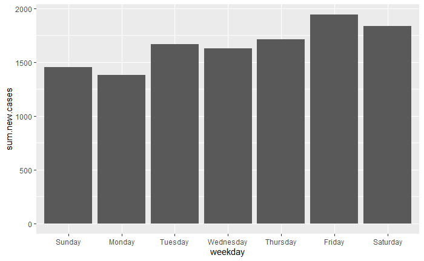

```r
ggplot(frequency.by.weekday, aes(weekday, sum.new.cases)) +
  geom_col()
```

Distribution of cases per day

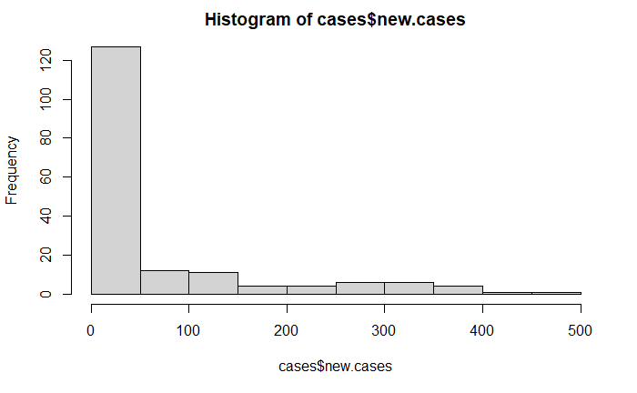

```r
hist(cases$new.cases)
```

Is bias due to a few very big case days? They absolutely bias the results. Unsure how to account for this yet.

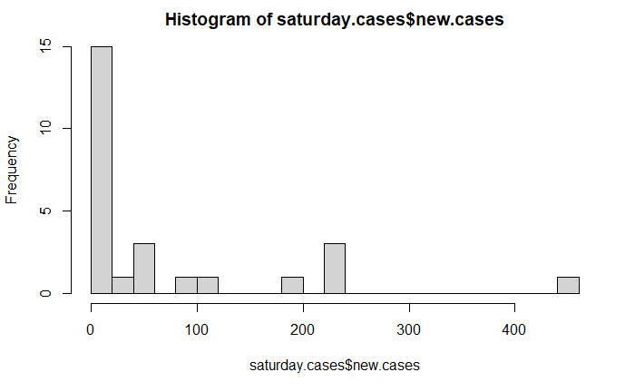

```r
saturday.cases <- cases %>% filter(weekday == "Saturday")
hist(saturday.cases$new.cases, breaks = dim(saturday.cases)[1])
```

Maybe should try graphing this.

Will need to normalise so that each graph has same magnitude. I think if I take min(x) for vector x of new.case counts for each 7 day interval it should at least be alright.

For the weekday with minimum new.cases per 7 day interval, there are sometimes multiple weekdays. In the seven.day stats table they are assigned “multiple”. I will make a separate table to illustrate all of them. Note that most multiple day counts come from early in the outbreak when there were many zero days.

```r
mins = c()
means = c()
maxs = c()
min_weekday <- c()
max_weekday <- c()
n_days <- c()
slopes <- c()

for (i in seq(2,dim(cases)[1],7)) {
  #select an interval of seven days from Sunday to Saturday
  index_7 <- i + 6
  temp.df <- cases[i:index_7,]
  temp.df <- drop_na(temp.df) #last entry might have NA rows

  #calculate a linear regression slope for each interval
  slopes <- append(slopes, coefficients(lm(new.cases~date, temp.df))['date'])

  # get mins and means
  mins <- append(mins, min(temp.df$new.cases))
  means <- append(means, mean(temp.df$new.cases))
  maxs <- append(maxs, max(temp.df$new.cases))

  #append unique weekdays which have min value
  min_weekday_temp <- filter(temp.df, new.cases == min(temp.df$new.cases))$weekday
  if (length(min_weekday_temp) > 1) {
    min_weekday_temp <- c("multiple")
  }
  min_weekday <- append(min_weekday, min_weekday_temp)

  #append unique weekdays which have max value
  max_weekday_temp <- filter(temp.df, new.cases == max(temp.df$new.cases))$weekday
  if (length(max_weekday_temp) > 1) {
    max_weekday_temp <- c("multiple")
  }
  max_weekday <- append(max_weekday, max_weekday_temp)

  #get number of days in each interval for debugging purposes
  n_days <- append(n_days, dim(temp.df)[1])
}
seven.day <- data.frame(date = dates, n_days = n_days, slopes = slopes,
                        mins = mins, means=means, maxs = maxs,
                        min_weekday = min_weekday, max_weekday = max_weekday)
seven.day
```

| date | n_days | slopes | mins | means | maxs | min_weekday | max_weekday |
| --- | --- | --- | --- | --- | --- | --- | --- |
| 2020-01-26 | 7 | 0.03571429 | 0 | 0.8571429 | 4 | multiple | Wednesday |
| 2020-02-02 | 7 | -0.21428571 | 0 | 0.7142857 | 2 | multiple | Sunday |
| 2020-02-09 | 7 | 0.00000000 | 0 | 0.0000000 | 0 | multiple | multiple |
| 2020-02-16 | 7 | 0.39285714 | 0 | 0.7142857 | 4 | multiple | Friday |
| 2020-02-23 | 7 | 0.25000000 | 0 | 0.7142857 | 3 | multiple | Thursday |
| 2020-03-01 | 7 | 0.75000000 | 3 | 6.8571429 | 11 | Sunday | Wednesday |
| 2020-03-08 | 7 | 7.14285714 | 7 | 25.1428571 | 51 | Sunday | Saturday |
| 2020-03-15 | 7 | 25.57142857 | 48 | 117.7142857 | 226 | Sunday | Saturday |
| 2020-03-22 | 7 | 22.53571429 | 280 | 367.1428571 | 460 | Sunday | Saturday |
| 2020-03-29 | 7 | -20.60714286 | 190 | 274.4285714 | 344 | Saturday | Sunday |

[output cut: 15 more lines]